# Basic Statistics Exercises Part 2

Author

Guy Schnidrig, Beatriz Vidondo

These are the exercises for [Basic Statistics and Projects in R](https://zuw.me/kurse/dt.php?kid=4474) course of the [Public Health Sciences Course Program](https://www.medizin.unibe.ch/studies/study_programs/phs_course_program) at the [University of Bern](https://www.unibe.ch/).

Ask [questions](https://app.sli.do/event/xpuz3U7hL5xXPjtRVmwfw7).

## 1 Non-Normality

Load the **cytomegalovirus** data from the package medicaldata<sup>[2](https://cran.r-project.org/web/packages/medicaldata/index.html)</sup>.  
Here you can find the full description<sup>[3](https://www.causeweb.org/tshs/datasets/Cytomegalovirus%20Dataset%20Introduction.pdf)</sup> of the study, as well as the code book<sup>[4](https://www.causeweb.org/tshs/datasets/Cytomegalovirus%20Data%20Dictionary.pdf)</sup>.

This data set contains 64 consecutive patients who underwent T-cell replete, matched sibling donor reduced-intensity conditioning allogeneic hematopoietic stem cell transplant. The primary risk factor of interest was the number of activating killer immunoglobulin-like receptors (aKIRs: 1-4 vs. 5-6). The primary outcome is **presence** of and **time to cytomegalovirus reactivation**.

```r
cytomegalovirus <- medicaldata::cytomegalovirus
```

Display the first 5 rows of the data set.

**Answer**

```r
head(cytomegalovirus,5) %>%
  kable()
```

| ID | age | sex | race | diagnosis | diagnosis.type | time.to.transplant | prior.radiation | prior.chemo | prior.transplant | recipient.cmv | donor.cmv | donor.sex | TNC.dose | CD34.dose | CD3.dose | CD8.dose | TBI.dose | C1/C2 | aKIRs | cmv | time.to.cmv | agvhd | time.to.agvhd | cgvhd | time.to.cgvhd |
| --- | --- | --- | --- | --- | --- | --- | --- | --- | --- | --- | --- | --- | --- | --- | --- | --- | --- | --- | --- | --- | --- | --- | --- | --- | --- |
| 1 | 61 | 1 | 0 | acute myeloid leukemia | 1 | 5.16 | 0 | 2 | 0 | 1 | 0 | 0 | 18.31 | 2.29 | 3.21 | 0.95 | 200 | 0 | 1 | 1 | 3.91 | 1 | 3.55 | 0 | 6.28 |
| 2 | 62 | 1 | 1 | non-Hodgkin lymphoma | 0 | 79.05 | 1 | 3 | 0 | 0 | 0 | 1 | 4.26 | 2.04 | NA | NA | 200 | 1 | 5 | 0 | 65.12 | 0 | 65.12 | 0 | 65.12 |
| 3 | 63 | 0 | 1 | non-Hodgkin lymphoma | 0 | 35.58 | 0 | 4 | 0 | 1 | 1 | 0 | 8.09 | 6.97 | 2.19 | 0.59 | 200 | 0 | 3 | 0 | 3.75 | 0 | 3.75 | 0 | 3.75 |
| 4 | 33 | 0 | 1 | Hodgkin lymphoma | 0 | 33.02 | 1 | 4 | 0 | 1 | 0 | 1 | 21.02 | 6.09 | 4.87 | 2.32 | 200 | 0 | 2 | 0 | 48.49 | 1 | 28.55 | 1 | 10.45 |
| 5 | 54 | 0 | 1 | acute lymphoblastic leukemia | 0 | 11.40 | 0 | 5 | 0 | 1 | 1 | 0 | 14.70 | 2.36 | 6.55 | 2.40 | 400 | 0 | 6 | 0 | 4.37 | 1 | 2.79 | 0 | 4.37 |

Plot a histogram of the time cytomegalovirus reactivation. Use `ggplot2` and set 20 bins (or use `geom_density`). What kind of distribution do you observe?

**Answer**

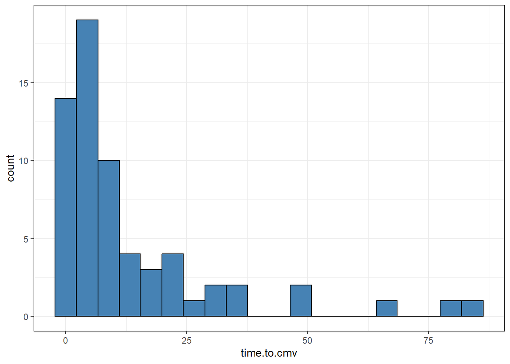

```r
cytomegalovirus %>%
  ggplot(aes(time.to.cmv)) +
  geom_histogram(bins = 20,
                 color = "black",
                 fill = "steelblue") +
  theme_bw()
```

Generate a quantile-quantile (QQ) plot using `geom_qq` and `geom_qq_line` to assess its alignment with the theoretical line.

**Answer**

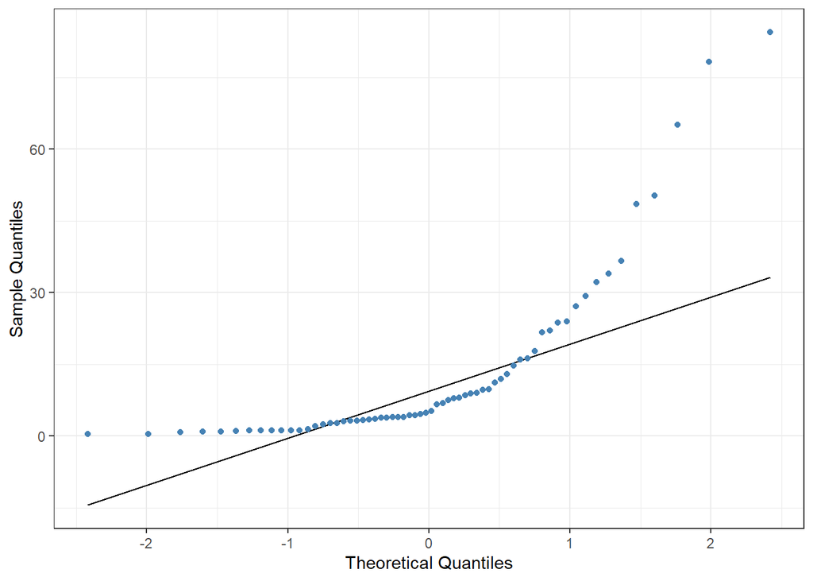

```r
cytomegalovirus %>%
  ggplot(aes(sample = time.to.cmv)) +
  geom_qq_line(distribution = stats::qnorm) +
  geom_qq(color = "steelblue", distribution = stats::qnorm) +
  xlab("Theoretical Quantiles") +
  ylab("Sample Quantiles") +
  theme_bw()
```

We can also test if the distribution is non normal. Use `shapiro_test` to test the null hypothesis that the data came from a normal distribution. Can you reject the null hypothesis?

**Answer**

```r
cytomegalovirus %>%
  shapiro_test(time.to.cmv) %>%
  kable(digits = 10)
```

| variable | statistic | p |
| --- | --- | --- |
| time.to.cmv | 0.6826074 | 0.0000000002 |

Try using `shapiro_test` for multiple variables and save the results in a `tibble`.

**Answer**

```r
shapiro_tests <- cytomegalovirus %>%
  shapiro_test(time.to.cmv, CD34.dose, CD3.dose)

shapiro_tests %>%
  kable(digits = 10)
```

| variable | statistic | p |
| --- | --- | --- |
| CD3.dose | 0.9734567 | 0.2062409782 |
| CD34.dose | 0.8884442 | 0.0000301618 |
| time.to.cmv | 0.6826074 | 0.0000000002 |

**Answer**

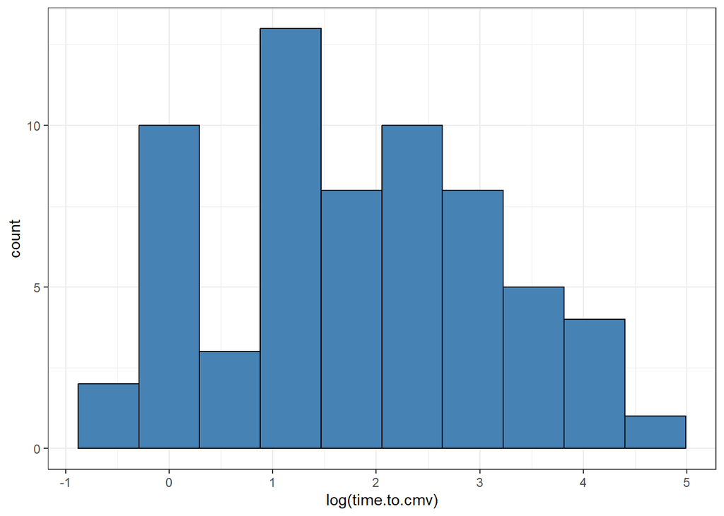

```r
cytomegalovirus %>%
  ggplot(aes(log(time.to.cmv))) +
  geom_histogram(color ="black",
                 fill = "steelblue",
                 bins = 10) +
  theme_bw()
```

**Answer**

```r
cytomegalovirus %>%
  mutate(log_time.to.cmv = log(time.to.cmv)) %>%
  shapiro_test(log_time.to.cmv) %>%
  kable(digits = 10)
```

| variable | statistic | p |
| --- | --- | --- |
| log_time.to.cmv | 0.9783012 | 0.3194252 |

The Kolmogorov-Smirnov test is a Normality test. Apply this test using function `ks.test` to variables **CD34.dose** and **CD3.dose**. What is the null hypothesis of `ks.test` and can you reject it?

**Answer**

```r
ks.test(cytomegalovirus$CD34.dose,cytomegalovirus$CD3.dose, "pnorm")
```

```
    Exact two-sample Kolmogorov-Smirnov test

data:  cytomegalovirus$CD34.dose and cytomegalovirus$CD3.dose
D = 0.3814, p-value = 0.0001259
alternative hypothesis: two-sided
```

Calculate if the mean **time to cytomegalovirus** reactivation differs between the sexes. Use the `wilcox_test`.

**Answer**

```r
cytomegalovirus %>%
  wilcox_test(time.to.cmv ~ sex) %>%
  kable()
```

| .y. | group1 | group2 | n1 | n2 | statistic | p |
| --- | --- | --- | --- | --- | --- | --- |
| time.to.cmv | 0 | 1 | 30 | 34 | 475.5 | 0.647 |

Use `geom_boxplot` and `fill` within `ggplot` to visualize your previous result.

**Answer**

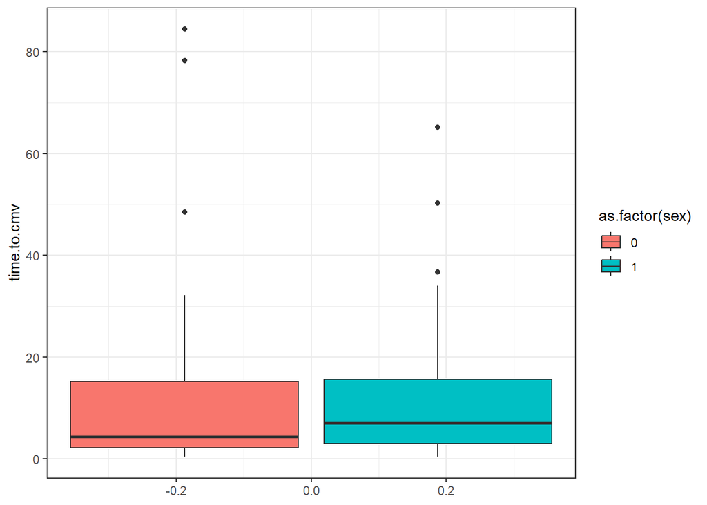

```r
cytomegalovirus %>%
  ggplot(aes(y = time.to.cmv, fill = as.factor(sex))) +
  geom_boxplot() +
  theme_bw()
```

When comparing more than two non-Normal (independent) groups, you can use R function `pairwise_wilcox_test`. In the example below, we create data of students scores in 3 groups A, B and C. Which correction method should you apply? Interpret your results.

```r
student_scores <- data.frame(
  Group = rep(c("A", "B", "C"), each = 5),
  Score1 = c(23, 25, 21, 20, 22, 18, 19, 24, 27, 26, 30, 28, 32, 29, 27),
  Score2 = c(19, 18, 17, 16, 13, 20, 15, 22, 25, 24, 26, 4, 30, 22, 13))

student_scores %>%
  kable()
```

| Group | Score1 | Score2 |
| --- | --- | --- |
| A | 23 | 19 |
| A | 25 | 18 |
| A | 21 | 17 |
| A | 20 | 16 |
| A | 22 | 13 |
| B | 18 | 20 |
| B | 19 | 15 |
| B | 24 | 22 |
| B | 27 | 25 |
| B | 26 | 24 |
| C | 30 | 26 |
| C | 28 | 4 |
| C | 32 | 30 |
| C | 29 | 22 |
| C | 27 | 13 |

**Answer**

```r
student_scores %>%
  pairwise_wilcox_test(Score1 ~ Group) %>%
  adjust_pvalue(method = "bonferroni") %>%
  add_significance("p.adj") %>%
  kable(digits = 5)
```

| .y. | group1 | group2 | n1 | n2 | statistic | p | p.adj | p.adj.signif |
| --- | --- | --- | --- | --- | --- | --- | --- | --- |
| Score1 | A | B | 5 | 5 | 11.0 | 0.841 | 1.000 | ns |
| Score1 | A | C | 5 | 5 | 0.0 | 0.008 | 0.024 | * |
| Score1 | B | C | 5 | 5 | 0.5 | 0.016 | 0.048 | * |

## 2 Correlation

Create a correlation matrix of all numerical measurements in **cytomegalovirus** data. Use `cor`, specify the `spearman` method and only include complete observations. Are there any variables that exhibit a higher degree of correlation with each other?

**Answer**

```r
cor_matrix <- cytomegalovirus %>%
  dplyr::select(time.to.transplant, TNC.dose, CD34.dose, CD3.dose, CD8.dose, TBI.dose, time.to.cmv, time.to.agvhd, time.to.cgvhd) %>%
  cor(use = "complete.obs", method = "spearman")

cor_matrix %>%
  kable(digits = 2)
```

|  | time.to.transplant | TNC.dose | CD34.dose | CD3.dose | CD8.dose | TBI.dose | time.to.cmv | time.to.agvhd | time.to.cgvhd |
| --- | --- | --- | --- | --- | --- | --- | --- | --- | --- |
| time.to.transplant | 1.00 | 0.07 | 0.10 | -0.10 | -0.03 | 0.11 | 0.21 | -0.02 | -0.11 |
| TNC.dose | 0.07 | 1.00 | 0.02 | 0.45 | 0.66 | -0.27 | -0.11 | 0.08 | 0.35 |
| CD34.dose | 0.10 | 0.02 | 1.00 | 0.11 | 0.10 | -0.46 | 0.05 | 0.10 | 0.16 |
| CD3.dose | -0.10 | 0.45 | 0.11 | 1.00 | 0.66 | 0.21 | -0.12 | 0.16 | 0.21 |
| CD8.dose | -0.03 | 0.66 | 0.10 | 0.66 | 1.00 | -0.18 | 0.05 | 0.10 | 0.31 |
| TBI.dose | 0.11 | -0.27 | -0.46 | 0.21 | -0.18 | 1.00 | 0.07 | 0.01 | -0.30 |
| time.to.cmv | 0.21 | -0.11 | 0.05 | -0.12 | 0.05 | 0.07 | 1.00 | 0.17 | 0.06 |
| time.to.agvhd | -0.02 | 0.08 | 0.10 | 0.16 | 0.10 | 0.01 | 0.17 | 1.00 | 0.43 |
| time.to.cgvhd | -0.11 | 0.35 | 0.16 | 0.21 | 0.31 | -0.30 | 0.06 | 0.43 | 1.00 |

Plot the lower half of your correlation matrix with `ggcorplot`.

**Answer**

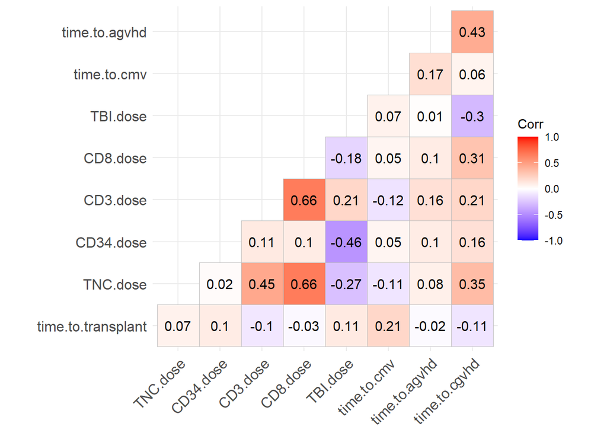

```r
ggcorrplot(cor_matrix, type = "lower", lab = TRUE)
```

**Answer**

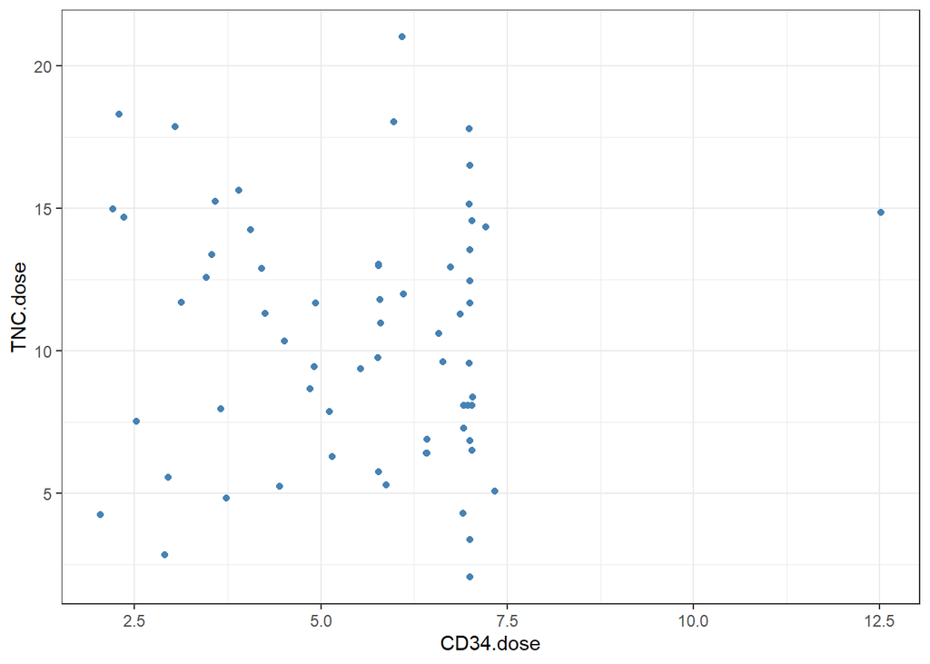

```r
cytomegalovirus %>%
  ggplot(aes(CD34.dose, TNC.dose)) +
  geom_point(color = "steelblue") + theme_bw()
```

Remove the outlier, run the correlation test again and choose the according method. Can you explain what has changed?

**Answer**

```r
cytomegalovirus %>%
  filter(CD34.dose <= 7.5) %>%
  dplyr::select(CD34.dose, TNC.dose) %>%
  cor(use = "complete.obs", method = "spearman") %>%
  kable(digits = 2)
```

|  | CD34.dose | TNC.dose |
| --- | --- | --- |
| CD34.dose | 1.0 | -0.1 |
| TNC.dose | -0.1 | 1.0 |

## 3 Dependent Data

Load the data **HorseBeginners** with Actual and Imaginary performances in equitation. Different riders reported how they performed in reality (**Actual**) and according to their own perception (**Imaginary**). In which format is this data (wide or long format)?

**Answer**

```r
data(HorseBeginners)

head(HorseBeginners, 5) %>%
  kable()
```

| Subject | Actual | Imaginary |
| --- | --- | --- |
| S1 | 69.64 | 66.58 |
| S2 | 62.26 | 25.59 |
| S3 | 78.63 | 24.01 |
| S4 | 76.00 | 38.35 |
| S5 | 60.10 | 12.19 |

Plot a Bland-Altman plot (`paired.plotBA`) and interpret it, Can you identify any outliers? on which subject?

**Answer**

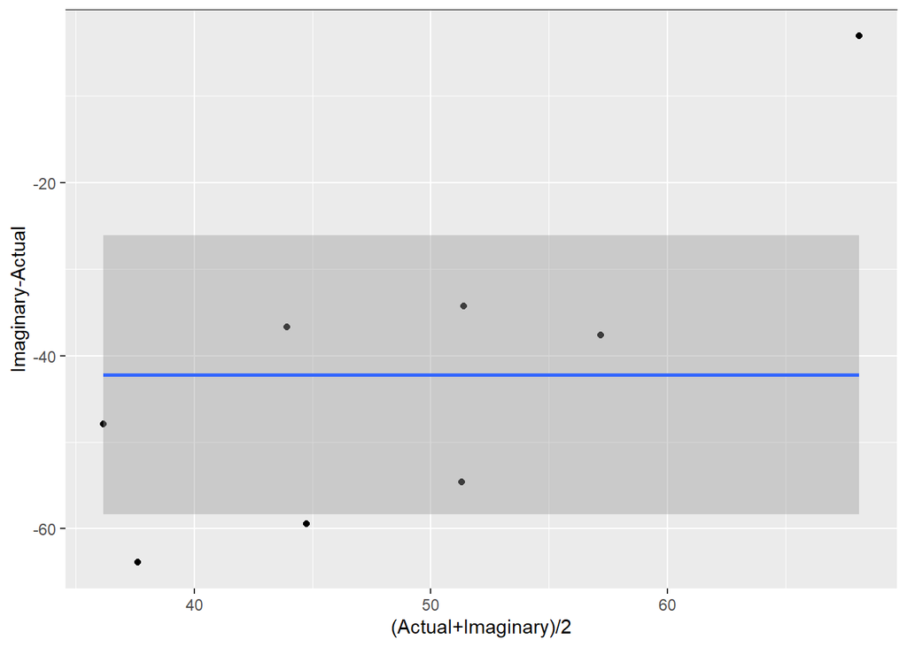

```r
paired.plotBA(HorseBeginners,"Actual","Imaginary")
```

**Answer**

Subject S1 is an outlier because it is the only one of all subjects for whom the imaginary performance is closer to actual performance.

Modify (pivot) the format of the dataset from wide into long format. For this you can use functions `pivot_longer` or `gather`and will need to create new variables (Performance and Type). Additionally, convert the categorical variables (Suject and Type) into factors (function `convert_as_factor`). How many times does every subject appear in the data now?

**Answer**

```r
HorseBeginnersL <- HorseBeginners %>%
  gather(key = "Type", value = "Performance", Actual,Imaginary) %>%
  convert_as_factor(Subject, Type)

head(HorseBeginnersL, 5) %>%
  kable()
```

| Subject | Type | Performance |
| --- | --- | --- |
| S1 | Actual | 69.64 |
| S2 | Actual | 62.26 |
| S3 | Actual | 78.63 |
| S4 | Actual | 76.00 |
| S5 | Actual | 60.10 |

**Answer**

Two times

Plot a profile plot (box plots of Performance by Type and lines connecting every subject). Can you identify the outlier at S1? Hint: use `geom_boxplot`, `geom_point`, and `geom_line`.

**Answer**

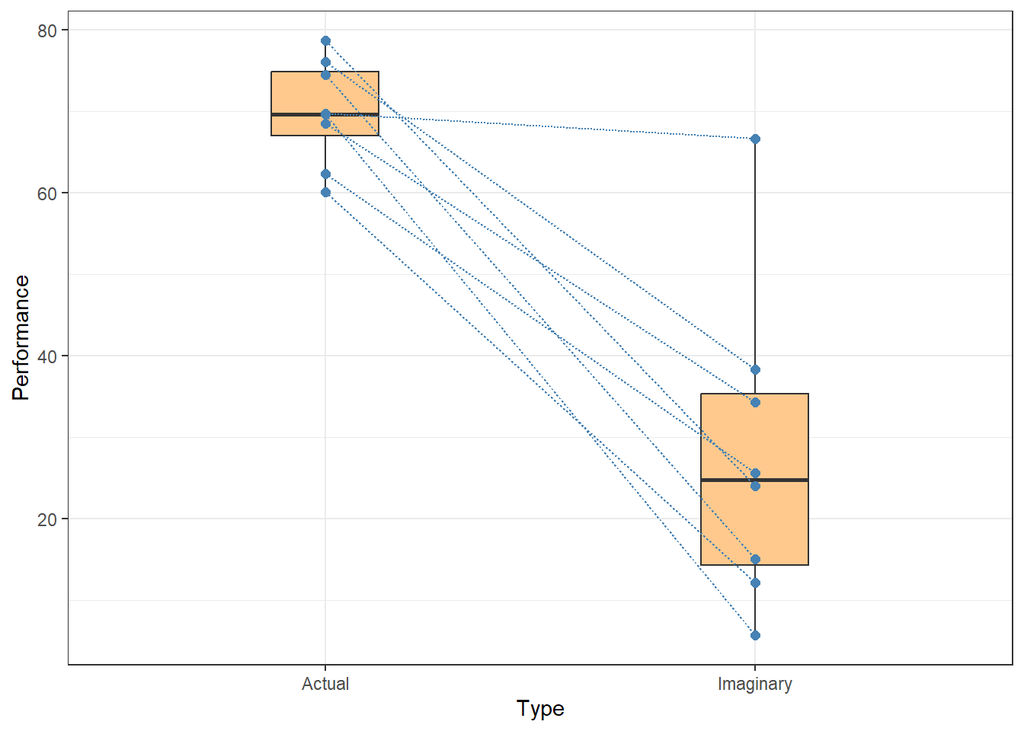

```r
HorseBeginnersL %>%
  ggplot(aes(Type, Performance)) +
  geom_boxplot(width = 0.25, fill = "#FFC98D") +
  geom_point(colour ="steelblue", size = 2) +
  geom_line(aes(group = Subject), colour = "steelblue", linetype = "11") +
  theme_bw()
```

Filter out the outlier (for the sake of the exercise).

**Answer**

```r
HorseBeginnersL_out <- HorseBeginnersL %>%
  filter(Subject != "S1")
```

Calculate the variability (SumOfSquares) between and within Subjects using the `aov` command. (Hint: Performance ~ Subject)

**Answer**

```r
anova_table <- aov(Performance ~ Subject, data = HorseBeginnersL_out)
summary(anova_table)
```

```
            Df Sum Sq Mean Sq F value Pr(>F)
Subject      6    710   118.4   0.098  0.994
Residuals    7   8416  1202.3
```

In this case, the Subject variable is interpreted as the Between variable. How many groups/clusters/subjects of data do you have?

**Answer**

S2 to S8, 7 groups/cluster of data, 7 subjects

How much is the total variability (SS-total)?

**Answer**

```r
(710+8416)
```

```
[1] 9126
```

Calculate the ICC (for Subject level) and interpret it.

**Answer**

```r
ICC <- 710 / (710+8416)
ICC
```

```
[1] 0.07779969
```

ICC is the amount of variance at the Subject level 7.8%.

Advanced exercise: using package **rstatix** set up a [repeated measures Anova](https://www.datanovia.com/en/lessons/repeated) with the **HorseBeginners** and interpret it. Note that this calculation involves both Subject and Type.

**Answer**

```r
HorseBeginnersL %>%
  anova_test(dv = Performance, wid = Subject, within = Type) %>%
  get_anova_table()
```

```
ANOVA Table (type III tests)

  Effect DFn DFd      F       p p<.05   ges
1   Type   1   7 38.316 0.00045     * 0.713
```

Explore other functions presented in the tutorial like `identify_outliers` and `shapiro_test`.

Does the dataset HorseBeginnersL really have an outlier?

**Answer**

```r
HorseBeginnersL %>%
  group_by(Type) %>%
  identify_outliers(Performance)
```

```
[1] Type        Subject     Performance is.outlier  is.extreme
<0 rows> (or 0-length row.names)
```